# Actividad colaborativa en clase | Base de datos de virus de NCBI

Jacobo S, Josué B, Jesús S

Creado por Josué Daniel Bahena Panécatl - A01424506 Jesús Sebastián Jaime Oviedo - A01412442 Jacobo Soffer - A01028653

```r
install.packages("seqinr")
```

En este cuaderno se muestra como se pueden obtener secuencias para diferentes viruses, y hacer operaciones con ellas a través de la librería `seqinr`. El método usado es el mismo para todos los viruses, a excepción de que algunas secuencias son descargadas directamente de la base de datos, mientras que otras son leídas de un archivo, donde estan almacenadas en el formato FASTA. Primero que nada, declaramos las variables donde se van a almacenar las tablas que contengan las composición de nucleótidos de cada secuencia:

```r
zikaTable <- c()
sarsTable <- c()
covid19Table <- c()
mersTable <- c()
dengueTable <- c()
influenzaTable <- c()
```

A continuación, la el analísis del virus Zika. Primero obtenemos la secuencia del virus de la base de datos “refSeq”, usando su número de acceso (AC):

```r
choosebank("refseqViruses")
res<-query("Zika1", "AC=NC_012532")
secu<-getSequence(res$req[[1]])
zikaTable <- table(secu)
```

Una vez que contamos con la secuencia, podemos realizar operaciones sobre ella. Esto es lo que hace el código a continuación, la mayoría de las funciones son obtenidas de la librería `seqinr` y son muy sencillas. Se usa la función `table()` a través del código para obtener una tabla que cuente la frecuencia con la que aparece cada base en la secuencia, y la función `table.prop()` para obtener una tabla que muestre el porcentage de cada base en la secuencia. La función `barplot()`es usada para graficar la frecuencia de cada base en la secuencia.

```r
print("1. ¿Cuál es el tamaño de cada secuencia?")
```

```
[1] "1. ¿Cuál es el tamaño de cada secuencia?"
```

```r
length(secu)
```

```
[1] 10794
```

```r
print("3. ¿Cuál es el contenido de GC?")
```

```
[1] "3. ¿Cuál es el contenido de GC?"
```

```r
GC(secu)
```

```
[1] 0.5093571
```

```r
print("2. ¿Cúal es la composición de nucleótidos?")
```

```
[1] "2. ¿Cúal es la composición de nucleótidos?"
```

```r
print(secu)
```

```
   [1] "a" "g" "t" "t" "g" "t" "t" "g" "a" "t" "c" "t" "g" "t" "g" "t" "g" "a" "g" "t" "c" "a"
  [23] "g" "a" "c" "t" "g" "c" "g" "a" "c" "a" "g" "t" "t" "c" "g" "a" "g" "t" "c" "t" "g" "a"
  [45] "a" "g" "c" "g" "a" "g" "a" "g" "c" "t" "a" "a" "c" "a" "a" "c" "a" "g" "t" "a" "t" "c"
  [67] "a" "a" "c" "a" "g" "g" "t" "t" "t" "a" "a" "t" "t" "t" "g" "g" "a" "t" "t" "t" "g" "g"
  [89] "a" "a" "a" "c" "g" "a" "g" "a" "g" "t" "t" "t" "c" "t" "g" "g" "t" "c" "a" "t" "g" "a"
 [111] "a" "a" "a" "a" "c" "c" "c" "c" "a" "a" "a" "g" "a" "a" "g" "a" "a" "a" "t" "c" "c" "g"
 [133] "g" "a" "g" "g" "a" "t" "c" "c" "g" "g" "a" "t" "t" "g" "t" "c" "a" "a" "t" "a" "t" "g"
 [155] "c" "t" "a" "a" "a" "a" "c" "g" "c" "g" "g" "a" "g" "t" "a" "g" "c" "c" "c" "g" "t" "g"
 [177] "t" "a" "a" "a" "c" "c" "c" "c" "t" "t" "g" "g" "g" "a" "g" "g" "t" "t" "t" "g" "a" "a"
 [199] "g" "a" "g" "g" "t" "t" "g" "c" "c" "a" "g" "c" "c" "g" "g" "a" "c" "t" "t" "c" "t" "g"
 [221] "c" "t" "g" "g" "g" "t" "c" "a" "t" "g" "g" "a" "c" "c" "c" "a" "t" "c" "a" "g" "a" "a"
 [243] "t" "g" "g" "t" "t" "t" "t" "g" "g" "c" "g" "a" "t" "a" "c" "t" "a" "g" "c" "c" "t" "t"
 [265] "t" "t" "t" "g" "a" "g" "a" "t" "t" "t" "a" "c" "a" "g" "c" "a" "a" "t" "c" "a" "a" "g"
 [287] "c" "c" "a" "t" "c" "a" "c" "t" "g" "g" "g" "c" "c" "t" "t" "a" "t" "c" "a" "a" "c" "a"
 [309] "g" "a" "t" "g" "g" "g" "g" "t" "t" "c" "c" "g" "t" "g" "g" "g" "g" "a" "a" "a" "a" "a"
```

[output cut: 32 more lines]

```r
per <- prop.table(zikaTable)

kable(zikaTable, caption="Composición de Nucleótidos (Frecuencia)", col.names = c("Base", "Frecuencia"), label = "Tabla Composición", format="html", padding=2)
```

Composición de Nucleótidos (Frecuencia)

| Base | Frecuencia |
| --- | --- |
| a | 2991 |
| c | 2359 |
| g | 3139 |
| t | 2305 |

```r
kable(per, caption="Composición de Nucleótidos (Porcentage)", col.names = c("Base", "Porcentage"), label = "Tabla Composición", format="html", padding=2)
```

Composición de Nucleótidos (Porcentage)

| Base | Porcentage |
| --- | --- |
| a | 0.2770984 |
| c | 0.2185473 |
| g | 0.2908097 |
| t | 0.2135446 |

```r
print("4. Obtener la secuencia en complementaria e imprimirla")
```

```
[1] "4. Obtener la secuencia en complementaria e imprimirla"
```

```r
comp(secu)
```

```
   [1] "t" "c" "a" "a" "c" "a" "a" "c" "t" "a" "g" "a" "c" "a" "c" "a" "c" "t" "c" "a" "g" "t"
  [23] "c" "t" "g" "a" "c" "g" "c" "t" "g" "t" "c" "a" "a" "g" "c" "t" "c" "a" "g" "a" "c" "t"
  [45] "t" "c" "g" "c" "t" "c" "t" "c" "g" "a" "t" "t" "g" "t" "t" "g" "t" "c" "a" "t" "a" "g"
  [67] "t" "t" "g" "t" "c" "c" "a" "a" "a" "t" "t" "a" "a" "a" "c" "c" "t" "a" "a" "a" "c" "c"
  [89] "t" "t" "t" "g" "c" "t" "c" "t" "c" "a" "a" "a" "g" "a" "c" "c" "a" "g" "t" "a" "c" "t"
 [111] "t" "t" "t" "t" "g" "g" "g" "g" "t" "t" "t" "c" "t" "t" "c" "t" "t" "t" "a" "g" "g" "c"
 [133] "c" "t" "c" "c" "t" "a" "g" "g" "c" "c" "t" "a" "a" "c" "a" "g" "t" "t" "a" "t" "a" "c"
 [155] "g" "a" "t" "t" "t" "t" "g" "c" "g" "c" "c" "t" "c" "a" "t" "c" "g" "g" "g" "c" "a" "c"
 [177] "a" "t" "t" "t" "g" "g" "g" "g" "a" "a" "c" "c" "c" "t" "c" "c" "a" "a" "a" "c" "t" "t"
 [199] "c" "t" "c" "c" "a" "a" "c" "g" "g" "t" "c" "g" "g" "c" "c" "t" "g" "a" "a" "g" "a" "c"
 [221] "g" "a" "c" "c" "c" "a" "g" "t" "a" "c" "c" "t" "g" "g" "g" "t" "a" "g" "t" "c" "t" "t"
 [243] "a" "c" "c" "a" "a" "a" "a" "c" "c" "g" "c" "t" "a" "t" "g" "a" "t" "c" "g" "g" "a" "a"
 [265] "a" "a" "a" "c" "t" "c" "t" "a" "a" "a" "t" "g" "t" "c" "g" "t" "t" "a" "g" "t" "t" "c"
 [287] "g" "g" "t" "a" "g" "t" "g" "a" "c" "c" "c" "g" "g" "a" "a" "t" "a" "g" "t" "t" "g" "t"
 [309] "c" "t" "a" "c" "c" "c" "c" "a" "a" "g" "g" "c" "a" "c" "c" "c" "c" "t" "t" "t" "t" "t"
```

[output cut: 32 more lines]

```r
print("5. Gráfica")
```

```
[1] "5. Gráfica"
```

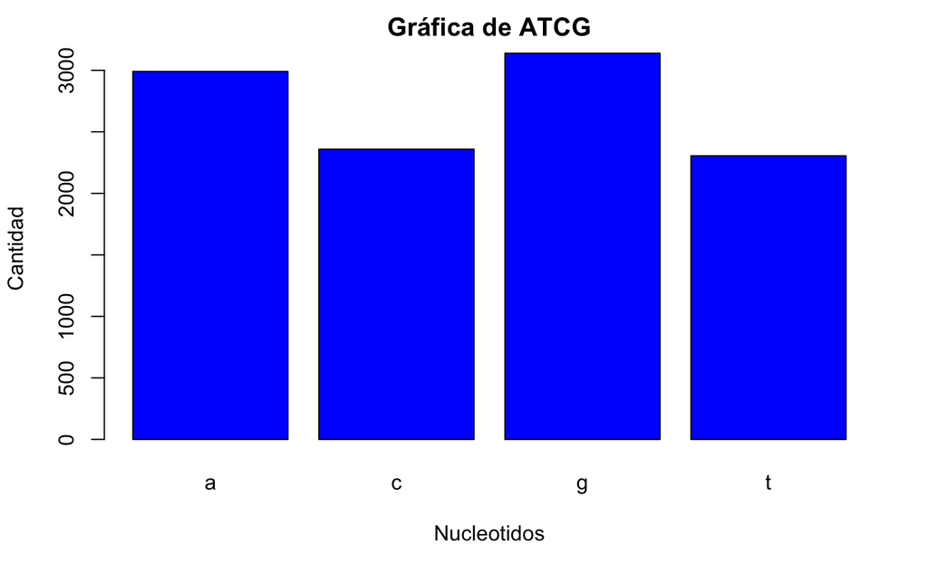

```r
barplot(zikaTable,
main = "Gráfica de ATCG",
xlab="Nucleotidos",
ylab="Cantidad",
col="blue",
)
```

```r
closebank()
```

El código anterior es usado para analizar las secuencias de los demás viruses en este cuaderno.

SARS 1

```r
choosebank("refseqViruses")

res<-query("Coronavirus", "AC= NC_004718")
secu<-getSequence(res$req[[1]])
sarsTable <- table(secu)

print("1. ¿Cuál es el tamaño de cada secuencia?")
```

```
[1] "1. ¿Cuál es el tamaño de cada secuencia?"
```

```r
length(secu)
```

```
[1] 29751
```

```r
print("3. ¿Cuál es el contenido de GC?")
```

```
[1] "3. ¿Cuál es el contenido de GC?"
```

```r
GC(secu)
```

```
[1] 0.4076166
```

```r
print("2. ¿Cúal es la composición de nucleótidos?")
```

```
[1] "2. ¿Cúal es la composición de nucleótidos?"
```

```r
print(secu)
```

```
   [1] "a" "t" "a" "t" "t" "a" "g" "g" "t" "t" "t" "t" "t" "a" "c" "c" "t" "a" "c" "c" "c" "a"
  [23] "g" "g" "a" "a" "a" "a" "g" "c" "c" "a" "a" "c" "c" "a" "a" "c" "c" "t" "c" "g" "a" "t"
  [45] "c" "t" "c" "t" "t" "g" "t" "a" "g" "a" "t" "c" "t" "g" "t" "t" "c" "t" "c" "t" "a" "a"
  [67] "a" "c" "g" "a" "a" "c" "t" "t" "t" "a" "a" "a" "a" "t" "c" "t" "g" "t" "g" "t" "a" "g"
  [89] "c" "t" "g" "t" "c" "g" "c" "t" "c" "g" "g" "c" "t" "g" "c" "a" "t" "g" "c" "c" "t" "a"
 [111] "g" "t" "g" "c" "a" "c" "c" "t" "a" "c" "g" "c" "a" "g" "t" "a" "t" "a" "a" "a" "c" "a"
 [133] "a" "t" "a" "a" "t" "a" "a" "a" "t" "t" "t" "t" "a" "c" "t" "g" "t" "c" "g" "t" "t" "g"
 [155] "a" "c" "a" "a" "g" "a" "a" "a" "c" "g" "a" "g" "t" "a" "a" "c" "t" "c" "g" "t" "c" "c"
 [177] "c" "t" "c" "t" "t" "c" "t" "g" "c" "a" "g" "a" "c" "t" "g" "c" "t" "t" "a" "c" "g" "g"
 [199] "t" "t" "t" "c" "g" "t" "c" "c" "g" "t" "g" "t" "t" "g" "c" "a" "g" "t" "c" "g" "a" "t"
 [221] "c" "a" "t" "c" "a" "g" "c" "a" "t" "a" "c" "c" "t" "a" "g" "g" "t" "t" "t" "c" "g" "t"
 [243] "c" "c" "g" "g" "g" "t" "g" "t" "g" "a" "c" "c" "g" "a" "a" "a" "g" "g" "t" "a" "a" "g"
 [265] "a" "t" "g" "g" "a" "g" "a" "g" "c" "c" "t" "t" "g" "t" "t" "c" "t" "t" "g" "g" "t" "g"
 [287] "t" "c" "a" "a" "c" "g" "a" "g" "a" "a" "a" "a" "c" "a" "c" "a" "c" "g" "t" "c" "c" "a"
 [309] "a" "c" "t" "c" "a" "g" "t" "t" "t" "g" "c" "c" "t" "g" "t" "c" "c" "t" "t" "c" "a" "g"
```

[output cut: 32 more lines]

```r
per <- prop.table(sarsTable)

kable(sarsTable, caption="Composición de Nucleótidos (Frecuencia)", col.names = c("Base", "Frecuencia"), label = "Tabla Composición", format="html", padding=2)
```

Composición de Nucleótidos (Frecuencia)

| Base | Frecuencia |
| --- | --- |
| a | 8481 |
| c | 5940 |
| g | 6187 |
| t | 9143 |

```r
kable(per, caption="Composición de Nucleótidos (Porcentage)", col.names = c("Base", "Porcentage"), label = "Tabla Composición", format="html", padding=2)
```

Composición de Nucleótidos (Porcentage)

| Base | Porcentage |
| --- | --- |
| a | 0.2850660 |
| c | 0.1996572 |
| g | 0.2079594 |
| t | 0.3073174 |

```r
print("4. Obtener la secuencia en complementaria e imprimirla")
```

```
[1] "4. Obtener la secuencia en complementaria e imprimirla"
```

```r
comp(secu)
```

```
   [1] "t" "a" "t" "a" "a" "t" "c" "c" "a" "a" "a" "a" "a" "t" "g" "g" "a" "t" "g" "g" "g" "t"
  [23] "c" "c" "t" "t" "t" "t" "c" "g" "g" "t" "t" "g" "g" "t" "t" "g" "g" "a" "g" "c" "t" "a"
  [45] "g" "a" "g" "a" "a" "c" "a" "t" "c" "t" "a" "g" "a" "c" "a" "a" "g" "a" "g" "a" "t" "t"
  [67] "t" "g" "c" "t" "t" "g" "a" "a" "a" "t" "t" "t" "t" "a" "g" "a" "c" "a" "c" "a" "t" "c"
  [89] "g" "a" "c" "a" "g" "c" "g" "a" "g" "c" "c" "g" "a" "c" "g" "t" "a" "c" "g" "g" "a" "t"
 [111] "c" "a" "c" "g" "t" "g" "g" "a" "t" "g" "c" "g" "t" "c" "a" "t" "a" "t" "t" "t" "g" "t"
 [133] "t" "a" "t" "t" "a" "t" "t" "t" "a" "a" "a" "a" "t" "g" "a" "c" "a" "g" "c" "a" "a" "c"
 [155] "t" "g" "t" "t" "c" "t" "t" "t" "g" "c" "t" "c" "a" "t" "t" "g" "a" "g" "c" "a" "g" "g"
 [177] "g" "a" "g" "a" "a" "g" "a" "c" "g" "t" "c" "t" "g" "a" "c" "g" "a" "a" "t" "g" "c" "c"
 [199] "a" "a" "a" "g" "c" "a" "g" "g" "c" "a" "c" "a" "a" "c" "g" "t" "c" "a" "g" "c" "t" "a"
 [221] "g" "t" "a" "g" "t" "c" "g" "t" "a" "t" "g" "g" "a" "t" "c" "c" "a" "a" "a" "g" "c" "a"
 [243] "g" "g" "c" "c" "c" "a" "c" "a" "c" "t" "g" "g" "c" "t" "t" "t" "c" "c" "a" "t" "t" "c"
 [265] "t" "a" "c" "c" "t" "c" "t" "c" "g" "g" "a" "a" "c" "a" "a" "g" "a" "a" "c" "c" "a" "c"
 [287] "a" "g" "t" "t" "g" "c" "t" "c" "t" "t" "t" "t" "g" "t" "g" "t" "g" "c" "a" "g" "g" "t"
 [309] "t" "g" "a" "g" "t" "c" "a" "a" "a" "c" "g" "g" "a" "c" "a" "g" "g" "a" "a" "g" "t" "c"
```

[output cut: 32 more lines]

```r
print("5. Gráfica")
```

```
[1] "5. Gráfica"
```

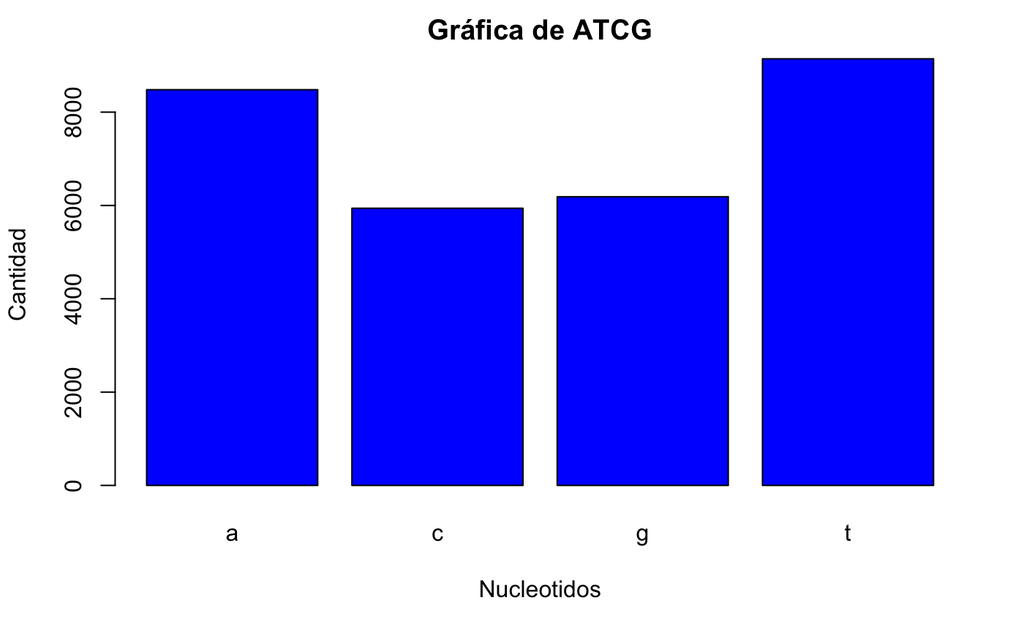

```r
#Table(secu) es util para contar los datos
barplot(sarsTable,
main = "Gráfica de ATCG",
xlab="Nucleotidos",
ylab="Cantidad",
col="blue",
)
```

```r
closebank()
```

SARS COV 2 Un ligero cambio que se puede observar a continuación, es que en lugar de descargar la secuencia de una base de datos, esta es leída de un archivo en el sistema conteniendola en formato FASTA. Esta es leída usando la función `read.fasta()`.

```r
library(seqinr);

#LEER DE MANERA LOCAL
res <- read.fasta("SARSCOV2.fasta", seqtype = "DNA")
secu<-res$NC_045512.2
covid19Table <- table(secu)

print("1. ¿Cuál es el tamaño de cada secuencia?")
```

```
[1] "1. ¿Cuál es el tamaño de cada secuencia?"
```

```r
length(secu)
```

```
[1] 29903
```

```r
print("3. ¿Cuál es el contenido de GC?")
```

```
[1] "3. ¿Cuál es el contenido de GC?"
```

```r
GC(secu)
```

```
[1] 0.3797278
```

```r
print("2. ¿Cúal es la composición de nucleótidos?")
```

```
[1] "2. ¿Cúal es la composición de nucleótidos?"
```

```r
print(secu)
```

```
   [1] "a" "t" "t" "a" "a" "a" "g" "g" "t" "t" "t" "a" "t" "a" "c" "c" "t" "t" "c" "c" "c" "a"
  [23] "g" "g" "t" "a" "a" "c" "a" "a" "a" "c" "c" "a" "a" "c" "c" "a" "a" "c" "t" "t" "t" "c"
  [45] "g" "a" "t" "c" "t" "c" "t" "t" "g" "t" "a" "g" "a" "t" "c" "t" "g" "t" "t" "c" "t" "c"
  [67] "t" "a" "a" "a" "c" "g" "a" "a" "c" "t" "t" "t" "a" "a" "a" "a" "t" "c" "t" "g" "t" "g"
  [89] "t" "g" "g" "c" "t" "g" "t" "c" "a" "c" "t" "c" "g" "g" "c" "t" "g" "c" "a" "t" "g" "c"
 [111] "t" "t" "a" "g" "t" "g" "c" "a" "c" "t" "c" "a" "c" "g" "c" "a" "g" "t" "a" "t" "a" "a"
 [133] "t" "t" "a" "a" "t" "a" "a" "c" "t" "a" "a" "t" "t" "a" "c" "t" "g" "t" "c" "g" "t" "t"
 [155] "g" "a" "c" "a" "g" "g" "a" "c" "a" "c" "g" "a" "g" "t" "a" "a" "c" "t" "c" "g" "t" "c"
 [177] "t" "a" "t" "c" "t" "t" "c" "t" "g" "c" "a" "g" "g" "c" "t" "g" "c" "t" "t" "a" "c" "g"
 [199] "g" "t" "t" "t" "c" "g" "t" "c" "c" "g" "t" "g" "t" "t" "g" "c" "a" "g" "c" "c" "g" "a"
 [221] "t" "c" "a" "t" "c" "a" "g" "c" "a" "c" "a" "t" "c" "t" "a" "g" "g" "t" "t" "t" "c" "g"
 [243] "t" "c" "c" "g" "g" "g" "t" "g" "t" "g" "a" "c" "c" "g" "a" "a" "a" "g" "g" "t" "a" "a"
 [265] "g" "a" "t" "g" "g" "a" "g" "a" "g" "c" "c" "t" "t" "g" "t" "c" "c" "c" "t" "g" "g" "t"
 [287] "t" "t" "c" "a" "a" "c" "g" "a" "g" "a" "a" "a" "a" "c" "a" "c" "a" "c" "g" "t" "c" "c"
 [309] "a" "a" "c" "t" "c" "a" "g" "t" "t" "t" "g" "c" "c" "t" "g" "t" "t" "t" "t" "a" "c" "a"
```

[output cut: 38 more lines]

```r
per <- prop.table(covid19Table)

kable(covid19Table, caption="Composición de Nucleótidos (Frecuencia)", col.names = c("Base", "Frecuencia"), label = "Tabla Composición", format="html", padding=2)
```

Composición de Nucleótidos (Frecuencia)

| Base | Frecuencia |
| --- | --- |
| a | 8954 |
| c | 5492 |
| g | 5863 |
| t | 9594 |

```r
kable(per, caption="Composición de Nucleótidos (Porcentage)", col.names = c("Base", "Porcentage"), label = "Tabla Composición", format="html", padding=2)
```

Composición de Nucleótidos (Porcentage)

| Base | Porcentage |
| --- | --- |
| a | 0.2994348 |
| c | 0.1836605 |
| g | 0.1960673 |
| t | 0.3208374 |

```r
print("4. Obtener la secuencia en complementaria e imprimirla")
```

```
[1] "4. Obtener la secuencia en complementaria e imprimirla"
```

```r
comp(secu)
```

```
   [1] "t" "a" "a" "t" "t" "t" "c" "c" "a" "a" "a" "t" "a" "t" "g" "g" "a" "a" "g" "g" "g" "t"
  [23] "c" "c" "a" "t" "t" "g" "t" "t" "t" "g" "g" "t" "t" "g" "g" "t" "t" "g" "a" "a" "a" "g"
  [45] "c" "t" "a" "g" "a" "g" "a" "a" "c" "a" "t" "c" "t" "a" "g" "a" "c" "a" "a" "g" "a" "g"
  [67] "a" "t" "t" "t" "g" "c" "t" "t" "g" "a" "a" "a" "t" "t" "t" "t" "a" "g" "a" "c" "a" "c"
  [89] "a" "c" "c" "g" "a" "c" "a" "g" "t" "g" "a" "g" "c" "c" "g" "a" "c" "g" "t" "a" "c" "g"
 [111] "a" "a" "t" "c" "a" "c" "g" "t" "g" "a" "g" "t" "g" "c" "g" "t" "c" "a" "t" "a" "t" "t"
 [133] "a" "a" "t" "t" "a" "t" "t" "g" "a" "t" "t" "a" "a" "t" "g" "a" "c" "a" "g" "c" "a" "a"
 [155] "c" "t" "g" "t" "c" "c" "t" "g" "t" "g" "c" "t" "c" "a" "t" "t" "g" "a" "g" "c" "a" "g"
 [177] "a" "t" "a" "g" "a" "a" "g" "a" "c" "g" "t" "c" "c" "g" "a" "c" "g" "a" "a" "t" "g" "c"
 [199] "c" "a" "a" "a" "g" "c" "a" "g" "g" "c" "a" "c" "a" "a" "c" "g" "t" "c" "g" "g" "c" "t"
 [221] "a" "g" "t" "a" "g" "t" "c" "g" "t" "g" "t" "a" "g" "a" "t" "c" "c" "a" "a" "a" "g" "c"
 [243] "a" "g" "g" "c" "c" "c" "a" "c" "a" "c" "t" "g" "g" "c" "t" "t" "t" "c" "c" "a" "t" "t"
 [265] "c" "t" "a" "c" "c" "t" "c" "t" "c" "g" "g" "a" "a" "c" "a" "g" "g" "g" "a" "c" "c" "a"
 [287] "a" "a" "g" "t" "t" "g" "c" "t" "c" "t" "t" "t" "t" "g" "t" "g" "t" "g" "c" "a" "g" "g"
 [309] "t" "t" "g" "a" "g" "t" "c" "a" "a" "a" "c" "g" "g" "a" "c" "a" "a" "a" "a" "t" "g" "t"
```

[output cut: 32 more lines]

```r
print("5. Gráfica")
```

```
[1] "5. Gráfica"
```

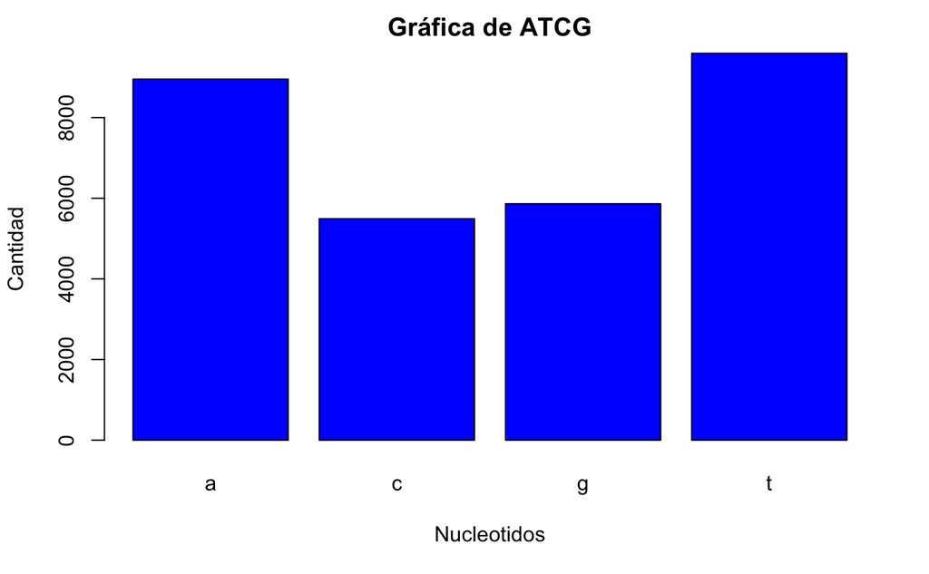

```r
#Table(secu) es util para contar los datos
barplot(covid19Table,
main = "Gráfica de ATCG",
xlab="Nucleotidos",
ylab="Cantidad",
col="blue",
)
```

MIDDLE EAST

```r
res <- read.fasta("MIDDLEEAST.fasta")
secu<-res$NC_019843.3
mersTable <- table(secu)

print("1. ¿Cuál es el tamaño de cada secuencia?")
```

```
[1] "1. ¿Cuál es el tamaño de cada secuencia?"
```

```r
length(secu)
```

```
[1] 30119
```

```r
print("3. ¿Cuál es el contenido de GC?")
```

```
[1] "3. ¿Cuál es el contenido de GC?"
```

```r
GC(secu)
```

```
[1] 0.4123643
```

```r
print("2. ¿Cúal es la composición de nucleótidos?")
```

```
[1] "2. ¿Cúal es la composición de nucleótidos?"
```

```r
print(secu)
```

```
   [1] "g" "a" "t" "t" "t" "a" "a" "g" "t" "g" "a" "a" "t" "a" "g" "c" "t" "t" "g" "g" "c" "t"
  [23] "a" "t" "c" "t" "c" "a" "c" "t" "t" "c" "c" "c" "c" "t" "c" "g" "t" "t" "c" "t" "c" "t"
  [45] "t" "g" "c" "a" "g" "a" "a" "c" "t" "t" "t" "g" "a" "t" "t" "t" "t" "a" "a" "c" "g" "a"
  [67] "a" "c" "t" "t" "a" "a" "a" "t" "a" "a" "a" "a" "g" "c" "c" "c" "t" "g" "t" "t" "g" "t"
  [89] "t" "t" "a" "g" "c" "g" "t" "a" "t" "c" "g" "t" "t" "g" "c" "a" "c" "t" "t" "g" "t" "c"
 [111] "t" "g" "g" "t" "g" "g" "g" "a" "t" "t" "g" "t" "g" "g" "c" "a" "t" "t" "a" "a" "t" "t"
 [133] "t" "g" "c" "c" "t" "g" "c" "t" "c" "a" "t" "c" "t" "a" "g" "g" "c" "a" "g" "t" "g" "g"
 [155] "a" "c" "a" "t" "a" "t" "g" "c" "t" "c" "a" "a" "c" "a" "c" "t" "g" "g" "g" "t" "a" "t"
 [177] "a" "a" "t" "t" "c" "t" "a" "a" "t" "t" "g" "a" "a" "t" "a" "c" "t" "a" "t" "t" "t" "t"
 [199] "t" "c" "a" "g" "t" "t" "a" "g" "a" "g" "c" "g" "t" "c" "g" "t" "g" "t" "c" "t" "c" "t"
 [221] "t" "g" "t" "a" "c" "g" "t" "c" "t" "c" "g" "g" "t" "c" "a" "c" "a" "a" "t" "a" "c" "a"
 [243] "c" "g" "g" "t" "t" "t" "c" "g" "t" "c" "c" "g" "g" "t" "g" "c" "g" "t" "g" "g" "c" "a"
 [265] "a" "t" "t" "c" "g" "g" "g" "g" "c" "a" "c" "a" "t" "c" "a" "t" "g" "t" "c" "t" "t" "t"
 [287] "c" "g" "t" "g" "g" "c" "t" "g" "g" "t" "g" "t" "g" "a" "c" "c" "g" "c" "g" "c" "a" "a"
 [309] "g" "g" "t" "g" "c" "g" "c" "g" "c" "g" "g" "t" "a" "c" "g" "t" "a" "t" "c" "g" "a" "g"
```

[output cut: 38 more lines]

```r
per <- prop.table(mersTable)

kable(mersTable, caption="Composición de Nucleótidos (Frecuencia)", col.names = c("Base", "Frecuencia"), label = "Tabla Composición", format="html", padding=2)
```

Composición de Nucleótidos (Frecuencia)

| Base | Frecuencia |
| --- | --- |
| a | 7900 |
| c | 6116 |
| g | 6304 |
| t | 9799 |

```r
kable(per, caption="Composición de Nucleótidos (Porcentage)", col.names = c("Base", "Porcentage"), label = "Tabla Composición", format="html", padding=2)
```

Composición de Nucleótidos (Porcentage)

| Base | Porcentage |
| --- | --- |
| a | 0.2622929 |
| c | 0.2030612 |
| g | 0.2093031 |
| t | 0.3253428 |

```r
print("4. Obtener la secuencia en complementaria e imprimirla")
```

```
[1] "4. Obtener la secuencia en complementaria e imprimirla"
```

```r
comp(secu)
```

```
   [1] "c" "t" "a" "a" "a" "t" "t" "c" "a" "c" "t" "t" "a" "t" "c" "g" "a" "a" "c" "c" "g" "a"
  [23] "t" "a" "g" "a" "g" "t" "g" "a" "a" "g" "g" "g" "g" "a" "g" "c" "a" "a" "g" "a" "g" "a"
  [45] "a" "c" "g" "t" "c" "t" "t" "g" "a" "a" "a" "c" "t" "a" "a" "a" "a" "t" "t" "g" "c" "t"
  [67] "t" "g" "a" "a" "t" "t" "t" "a" "t" "t" "t" "t" "c" "g" "g" "g" "a" "c" "a" "a" "c" "a"
  [89] "a" "a" "t" "c" "g" "c" "a" "t" "a" "g" "c" "a" "a" "c" "g" "t" "g" "a" "a" "c" "a" "g"
 [111] "a" "c" "c" "a" "c" "c" "c" "t" "a" "a" "c" "a" "c" "c" "g" "t" "a" "a" "t" "t" "a" "a"
 [133] "a" "c" "g" "g" "a" "c" "g" "a" "g" "t" "a" "g" "a" "t" "c" "c" "g" "t" "c" "a" "c" "c"
 [155] "t" "g" "t" "a" "t" "a" "c" "g" "a" "g" "t" "t" "g" "t" "g" "a" "c" "c" "c" "a" "t" "a"
 [177] "t" "t" "a" "a" "g" "a" "t" "t" "a" "a" "c" "t" "t" "a" "t" "g" "a" "t" "a" "a" "a" "a"
 [199] "a" "g" "t" "c" "a" "a" "t" "c" "t" "c" "g" "c" "a" "g" "c" "a" "c" "a" "g" "a" "g" "a"
 [221] "a" "c" "a" "t" "g" "c" "a" "g" "a" "g" "c" "c" "a" "g" "t" "g" "t" "t" "a" "t" "g" "t"
 [243] "g" "c" "c" "a" "a" "a" "g" "c" "a" "g" "g" "c" "c" "a" "c" "g" "c" "a" "c" "c" "g" "t"
 [265] "t" "a" "a" "g" "c" "c" "c" "c" "g" "t" "g" "t" "a" "g" "t" "a" "c" "a" "g" "a" "a" "a"
 [287] "g" "c" "a" "c" "c" "g" "a" "c" "c" "a" "c" "a" "c" "t" "g" "g" "c" "g" "c" "g" "t" "t"
 [309] "c" "c" "a" "c" "g" "c" "g" "c" "g" "c" "c" "a" "t" "g" "c" "a" "t" "a" "g" "c" "t" "c"
```

[output cut: 32 more lines]

```r
print("5. Gráfica")
```

```
[1] "5. Gráfica"
```

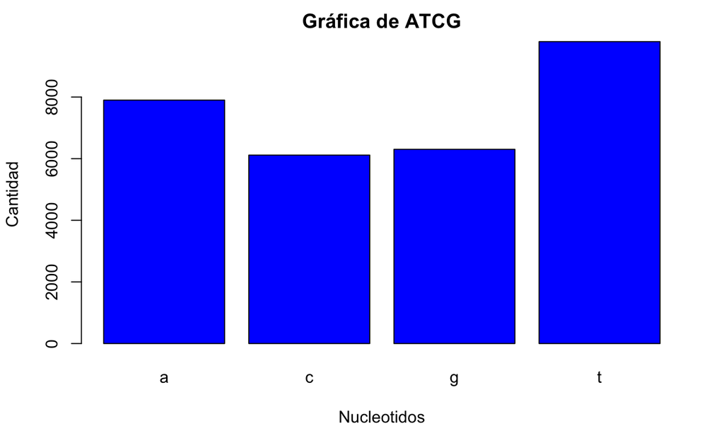

```r
#Table(secu) es util para contar los datos
barplot(mersTable,
main = "Gráfica de ATCG",
xlab="Nucleotidos",
ylab="Cantidad",
col="blue",
)
```

DENGUE

```r
choosebank("refseqViruses")

res<-query("Dengue1", "AC=NC_001477")
secu<-getSequence(res$req[[1]])
dengueTable <- table(secu)

print("1. ¿Cuál es el tamaño de cada secuencia?")
```

```
[1] "1. ¿Cuál es el tamaño de cada secuencia?"
```

```r
length(secu)
```

```
[1] 10735
```

```r
print("3. ¿Cuál es el contenido de GC?")
```

```
[1] "3. ¿Cuál es el contenido de GC?"
```

```r
GC(secu)
```

```
[1] 0.4666977
```

```r
print("2. ¿Cúal es la composición de nucleótidos?")
```

```
[1] "2. ¿Cúal es la composición de nucleótidos?"
```

```r
print(secu)
```

```
   [1] "a" "g" "t" "t" "g" "t" "t" "a" "g" "t" "c" "t" "a" "c" "g" "t" "g" "g" "a" "c" "c" "g"
  [23] "a" "c" "a" "a" "g" "a" "a" "c" "a" "g" "t" "t" "t" "c" "g" "a" "a" "t" "c" "g" "g" "a"
  [45] "a" "g" "c" "t" "t" "g" "c" "t" "t" "a" "a" "c" "g" "t" "a" "g" "t" "t" "c" "t" "a" "a"
  [67] "c" "a" "g" "t" "t" "t" "t" "t" "t" "a" "t" "t" "a" "g" "a" "g" "a" "g" "c" "a" "g" "a"
  [89] "t" "c" "t" "c" "t" "g" "a" "t" "g" "a" "a" "c" "a" "a" "c" "c" "a" "a" "c" "g" "g" "a"
 [111] "a" "a" "a" "a" "g" "a" "c" "g" "g" "g" "t" "c" "g" "a" "c" "c" "g" "t" "c" "t" "t" "t"
 [133] "c" "a" "a" "t" "a" "t" "g" "c" "t" "g" "a" "a" "a" "c" "g" "c" "g" "c" "g" "a" "g" "a"
 [155] "a" "a" "c" "c" "g" "c" "g" "t" "g" "t" "c" "a" "a" "c" "t" "g" "t" "t" "t" "c" "a" "c"
 [177] "a" "g" "t" "t" "g" "g" "c" "g" "a" "a" "g" "a" "g" "a" "t" "t" "c" "t" "c" "a" "a" "a"
 [199] "a" "g" "g" "a" "t" "t" "g" "c" "t" "t" "t" "c" "a" "g" "g" "c" "c" "a" "a" "g" "g" "a"
 [221] "c" "c" "c" "a" "t" "g" "a" "a" "a" "t" "t" "g" "g" "t" "g" "a" "t" "g" "g" "c" "t" "t"
 [243] "t" "t" "a" "t" "a" "g" "c" "a" "t" "t" "c" "c" "t" "a" "a" "g" "a" "t" "t" "t" "c" "t"
 [265] "a" "g" "c" "c" "a" "t" "a" "c" "c" "t" "c" "c" "a" "a" "c" "a" "g" "c" "a" "g" "g" "a"
 [287] "a" "t" "t" "t" "t" "g" "g" "c" "t" "a" "g" "a" "t" "g" "g" "g" "g" "c" "t" "c" "a" "t"
 [309] "t" "c" "a" "a" "g" "a" "a" "g" "a" "a" "t" "g" "g" "a" "g" "c" "g" "a" "t" "c" "a" "a"
```

[output cut: 32 more lines]

```r
per <- prop.table(dengueTable)

kable(dengueTable, caption="Composición de Nucleótidos (Frecuencia)", col.names = c("Base", "Frecuencia"), label = "Tabla Composición", format="html", padding=2)
```

Composición de Nucleótidos (Frecuencia)

| Base | Frecuencia |
| --- | --- |
| a | 3426 |
| c | 2240 |
| g | 2770 |
| t | 2299 |

```r
kable(per, caption="Composición de Nucleótidos (Porcentage)", col.names = c("Base", "Porcentage"), label = "Tabla Composición", format="html", padding=2)
```

Composición de Nucleótidos (Porcentage)

| Base | Porcentage |
| --- | --- |
| a | 0.3191430 |
| c | 0.2086633 |
| g | 0.2580345 |
| t | 0.2141593 |

```r
print("4. Obtener la secuencia en complementaria e imprimirla")
```

```
[1] "4. Obtener la secuencia en complementaria e imprimirla"
```

```r
comp(secu)
```

```
   [1] "t" "c" "a" "a" "c" "a" "a" "t" "c" "a" "g" "a" "t" "g" "c" "a" "c" "c" "t" "g" "g" "c"
  [23] "t" "g" "t" "t" "c" "t" "t" "g" "t" "c" "a" "a" "a" "g" "c" "t" "t" "a" "g" "c" "c" "t"
  [45] "t" "c" "g" "a" "a" "c" "g" "a" "a" "t" "t" "g" "c" "a" "t" "c" "a" "a" "g" "a" "t" "t"
  [67] "g" "t" "c" "a" "a" "a" "a" "a" "a" "t" "a" "a" "t" "c" "t" "c" "t" "c" "g" "t" "c" "t"
  [89] "a" "g" "a" "g" "a" "c" "t" "a" "c" "t" "t" "g" "t" "t" "g" "g" "t" "t" "g" "c" "c" "t"
 [111] "t" "t" "t" "t" "c" "t" "g" "c" "c" "c" "a" "g" "c" "t" "g" "g" "c" "a" "g" "a" "a" "a"
 [133] "g" "t" "t" "a" "t" "a" "c" "g" "a" "c" "t" "t" "t" "g" "c" "g" "c" "g" "c" "t" "c" "t"
 [155] "t" "t" "g" "g" "c" "g" "c" "a" "c" "a" "g" "t" "t" "g" "a" "c" "a" "a" "a" "g" "t" "g"
 [177] "t" "c" "a" "a" "c" "c" "g" "c" "t" "t" "c" "t" "c" "t" "a" "a" "g" "a" "g" "t" "t" "t"
 [199] "t" "c" "c" "t" "a" "a" "c" "g" "a" "a" "a" "g" "t" "c" "c" "g" "g" "t" "t" "c" "c" "t"
 [221] "g" "g" "g" "t" "a" "c" "t" "t" "t" "a" "a" "c" "c" "a" "c" "t" "a" "c" "c" "g" "a" "a"
 [243] "a" "a" "t" "a" "t" "c" "g" "t" "a" "a" "g" "g" "a" "t" "t" "c" "t" "a" "a" "a" "g" "a"
 [265] "t" "c" "g" "g" "t" "a" "t" "g" "g" "a" "g" "g" "t" "t" "g" "t" "c" "g" "t" "c" "c" "t"
 [287] "t" "a" "a" "a" "a" "c" "c" "g" "a" "t" "c" "t" "a" "c" "c" "c" "c" "g" "a" "g" "t" "a"
 [309] "a" "g" "t" "t" "c" "t" "t" "c" "t" "t" "a" "c" "c" "t" "c" "g" "c" "t" "a" "g" "t" "t"
```

[output cut: 32 more lines]

```r
print("5. Gráfica")
```

```
[1] "5. Gráfica"
```

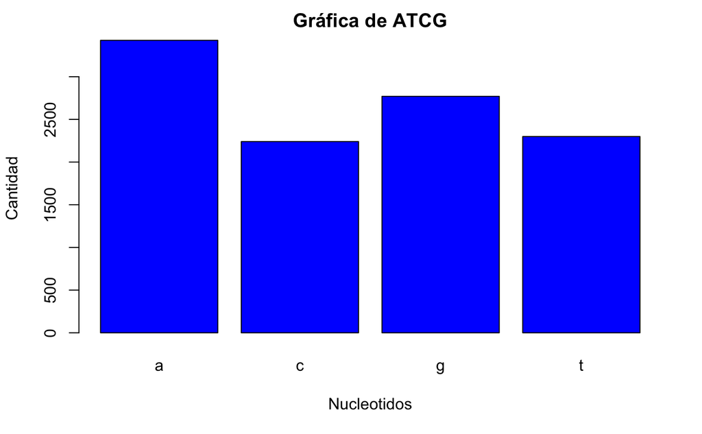

```r
#Table(secu) es util para contar los datos
barplot(dengueTable,
main = "Gráfica de ATCG",
xlab="Nucleotidos",
ylab="Cantidad",
col="blue",
)
```

```r
closebank();
```

Influenza H1N1 (2009)

```r
pb2 <- read.fasta("INFLUENZA_PB2_S1.txt")
s1 <- pb2$CY050205.1
pb1 <- read.fasta("INFLUENZA_PB1_S2.txt")
s2 <- pb1$CY050204.1
pa <- read.fasta("INFLUENZA_PA_S3.txt")
s3 <- pa$CY050203.1
ha <- read.fasta("INFLUENZA_HA_S4.txt")
s4 <- ha$CY050198.1
np <- read.fasta("INFLUENZA_NP_S5.txt")
s5 <- np$CY050201.1
na <- read.fasta("INFLUENZA_NA_S6.txt")
s6 <- na$CY050200.1
mp <- read.fasta("INFLUENZA_MP_S7.txt")
s7 <- mp$CY050199.1
ns <- read.fasta("INFLUENZA_NS_S8.txt")
s8 <- ns$CY050202.1

secu <- c(s1, s2, s3, s4, s5, s6, s7, s8)
influenzaTable <- table(secu)

print(testPer)
```

[output not shown]

```r
print("1. ¿Cuál es el tamaño de cada secuencia?")
```

```
[1] "1. ¿Cuál es el tamaño de cada secuencia?"
```

```r
length(secu)
```

```
[1] 13280
```

```r
print("3. ¿Cuál es el contenido de GC?")
```

```
[1] "3. ¿Cuál es el contenido de GC?"
```

```r
GC(secu)
```

```
[1] 0.4351657
```

```r
print("2. ¿Cúal es la composición de nucleótidos?")
```

```
[1] "2. ¿Cúal es la composición de nucleótidos?"
```

```r
print(secu)
```

```
   [1] "t" "a" "t" "g" "g" "a" "g" "a" "g" "a" "a" "t" "a" "a" "a" "a" "g" "a" "a" "c" "t" "g"
  [23] "a" "g" "a" "g" "a" "t" "c" "t" "a" "a" "t" "g" "t" "c" "g" "c" "a" "g" "t" "c" "c" "c"
  [45] "g" "c" "a" "c" "t" "c" "g" "c" "g" "a" "g" "a" "t" "a" "c" "t" "c" "a" "c" "t" "a" "a"
  [67] "g" "a" "c" "c" "a" "c" "t" "g" "t" "g" "g" "a" "c" "c" "a" "t" "a" "t" "g" "g" "c" "c"
  [89] "a" "t" "a" "a" "t" "c" "a" "a" "a" "a" "a" "g" "t" "a" "c" "a" "c" "a" "t" "c" "a" "g"
 [111] "g" "a" "a" "g" "g" "c" "a" "a" "g" "a" "g" "a" "a" "g" "a" "a" "c" "c" "c" "c" "g" "c"
 [133] "a" "c" "t" "c" "a" "g" "a" "a" "t" "g" "a" "a" "g" "t" "g" "g" "a" "t" "g" "a" "t" "g"
 [155] "g" "c" "a" "a" "t" "g" "a" "g" "a" "t" "a" "c" "c" "c" "a" "a" "t" "t" "a" "c" "a" "g"
 [177] "c" "a" "g" "a" "c" "a" "a" "g" "a" "g" "a" "a" "t" "a" "a" "t" "g" "g" "a" "c" "a" "t"
 [199] "g" "a" "t" "t" "c" "c" "a" "g" "a" "g" "a" "g" "g" "a" "a" "t" "g" "a" "a" "c" "a" "a"
 [221] "g" "g" "a" "c" "a" "a" "a" "c" "c" "c" "t" "c" "t" "g" "g" "a" "g" "c" "a" "a" "a" "a"
 [243] "c" "a" "a" "a" "c" "g" "a" "t" "g" "c" "t" "g" "g" "a" "t" "c" "a" "g" "a" "c" "c" "g"
 [265] "a" "g" "t" "g" "a" "t" "g" "g" "t" "a" "t" "c" "a" "c" "c" "t" "c" "t" "g" "g" "c" "c"
 [287] "g" "t" "a" "a" "c" "a" "t" "g" "g" "t" "g" "g" "a" "a" "t" "a" "g" "g" "a" "a" "t" "g"
 [309] "g" "c" "c" "c" "a" "a" "c" "a" "a" "c" "a" "a" "g" "t" "a" "c" "a" "g" "t" "t" "c" "a"
```

[output cut: 32 more lines]

```r
per <- prop.table(influenzaTable)

kable(influenzaTable, caption="Composición de Nucleótidos (Frecuencia)", col.names = c("Base", "Frecuencia"), label = "Tabla Composición", format="html", padding=2)
```

Composición de Nucleótidos (Frecuencia)

| Base | Frecuencia |
| --- | --- |
| a | 4434 |
| c | 2562 |
| g | 3217 |
| t | 3067 |

```r
kable(per, caption="Composición de Nucleótidos (Porcentage)", col.names = c("Base", "Porcentage"), label = "Tabla Composición", format="html", padding=2)
```

Composición de Nucleótidos (Porcentage)

| Base | Porcentage |
| --- | --- |
| a | 0.3338855 |
| c | 0.1929217 |
| g | 0.2422440 |
| t | 0.2309488 |

```r
print("4. Obtener la secuencia en complementaria e imprimirla")
```

```
[1] "4. Obtener la secuencia en complementaria e imprimirla"
```

```r
comp(secu)
```

```
   [1] "a" "t" "a" "c" "c" "t" "c" "t" "c" "t" "t" "a" "t" "t" "t" "t" "c" "t" "t" "g" "a" "c"
  [23] "t" "c" "t" "c" "t" "a" "g" "a" "t" "t" "a" "c" "a" "g" "c" "g" "t" "c" "a" "g" "g" "g"
  [45] "c" "g" "t" "g" "a" "g" "c" "g" "c" "t" "c" "t" "a" "t" "g" "a" "g" "t" "g" "a" "t" "t"
  [67] "c" "t" "g" "g" "t" "g" "a" "c" "a" "c" "c" "t" "g" "g" "t" "a" "t" "a" "c" "c" "g" "g"
  [89] "t" "a" "t" "t" "a" "g" "t" "t" "t" "t" "t" "c" "a" "t" "g" "t" "g" "t" "a" "g" "t" "c"
 [111] "c" "t" "t" "c" "c" "g" "t" "t" "c" "t" "c" "t" "t" "c" "t" "t" "g" "g" "g" "g" "c" "g"
 [133] "t" "g" "a" "g" "t" "c" "t" "t" "a" "c" "t" "t" "c" "a" "c" "c" "t" "a" "c" "t" "a" "c"
 [155] "c" "g" "t" "t" "a" "c" "t" "c" "t" "a" "t" "g" "g" "g" "t" "t" "a" "a" "t" "g" "t" "c"
 [177] "g" "t" "c" "t" "g" "t" "t" "c" "t" "c" "t" "t" "a" "t" "t" "a" "c" "c" "t" "g" "t" "a"
 [199] "c" "t" "a" "a" "g" "g" "t" "c" "t" "c" "t" "c" "c" "t" "t" "a" "c" "t" "t" "g" "t" "t"
 [221] "c" "c" "t" "g" "t" "t" "t" "g" "g" "g" "a" "g" "a" "c" "c" "t" "c" "g" "t" "t" "t" "t"
 [243] "g" "t" "t" "t" "g" "c" "t" "a" "c" "g" "a" "c" "c" "t" "a" "g" "t" "c" "t" "g" "g" "c"
 [265] "t" "c" "a" "c" "t" "a" "c" "c" "a" "t" "a" "g" "t" "g" "g" "a" "g" "a" "c" "c" "g" "g"
 [287] "c" "a" "t" "t" "g" "t" "a" "c" "c" "a" "c" "c" "t" "t" "a" "t" "c" "c" "t" "t" "a" "c"
 [309] "c" "g" "g" "g" "t" "t" "g" "t" "t" "g" "t" "t" "c" "a" "t" "g" "t" "c" "a" "a" "g" "t"
```

[output cut: 32 more lines]

```r
print("5. Gráfica")
```

```
[1] "5. Gráfica"
```

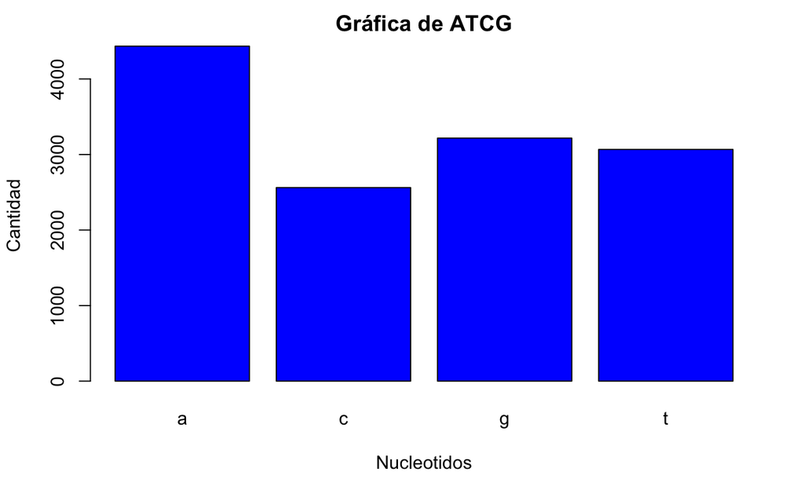

```r
#Table(secu) es util para contar los datos
barplot(influenzaTable,
main = "Gráfica de ATCG",
xlab="Nucleotidos",
ylab="Cantidad",
col="blue",
)
```

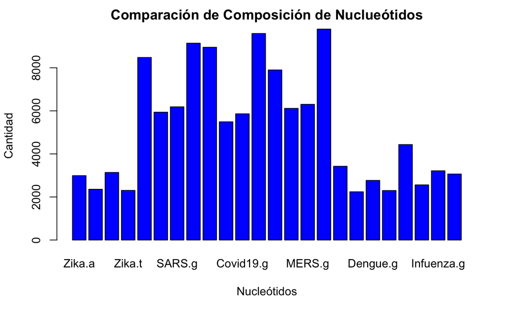

```r
test <- c(Zika = zikaTable, SARS = sarsTable, Covid19 = covid19Table, MERS = mersTable, Dengue = dengueTable, Infuenza = influenzaTable)

barplot(test,
  main = "Comparación de Composición de Nuclueótidos",
  xlab = "Nucleótidos",
  ylab = "Cantidad",
  col = "blue"
)
```